# MLE Computer Homework

[Bryant Chon]

02 December, 2021

```r
knitr::opts_chunk$set(echo = TRUE)
library("tidyverse") #to load ggplot() and read_csv() functions
data_obs <- rexp(1000, rate = 1/3.2)
```

# Instructions

- fill in your full name in the `author` field above
- `save as` this file as a separate *.rmd file, and replace “template” with your full name
- read through the examples below
- finish the exercises

# Examples

## Maximum Likelihood Estimate with the Poisson Distribution

### Synthetic Data

Source: https://cmdlinetips.com/2019/03/introduction-to-maximum-likelihood-estimation-in-r/

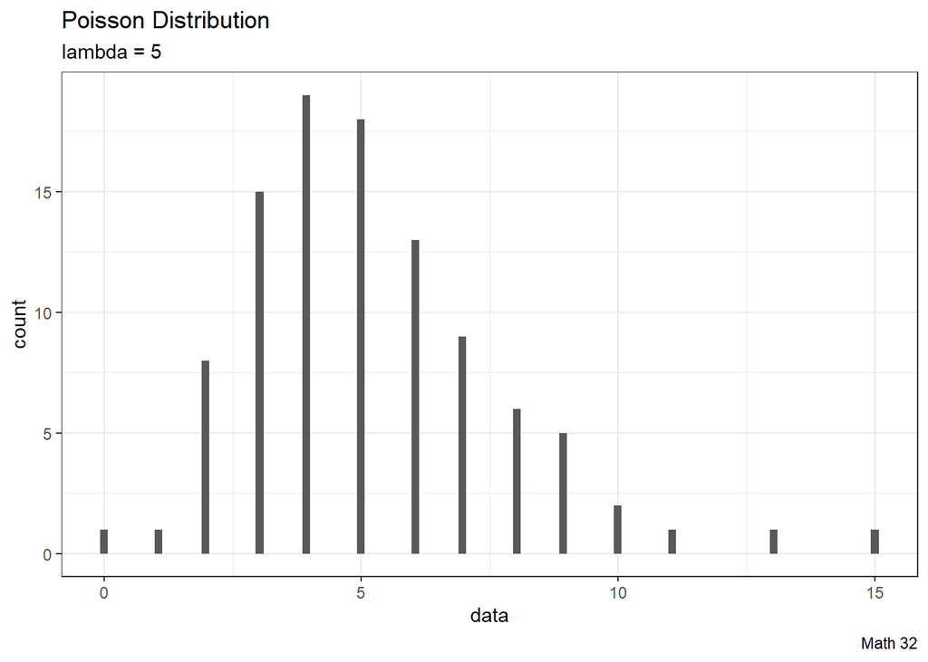

```r
# generate data from Poisson distribution with the parameter lambda = 5
N <- 100 #sample size
data_pois <- rpois(n = N, lambda = 5)

# convert to data frame
df_Poisson <- data.frame(data_pois)

# plot data
df_Poisson %>%
  ggplot(aes(x=data_pois))+
  geom_histogram(bins = N) +
  labs(title = "Poisson Distribution",
       subtitle = "lambda = 5",
       caption = "Math 32",
       x = "data",
       y = "count") +
  theme_bw()
```

### Likelihood

```r
# likelihood of a single data point, guessing lambda = 1
dpois(data_pois[1], lambda = 1)
```

```
## [1] 1.013777e-06
```

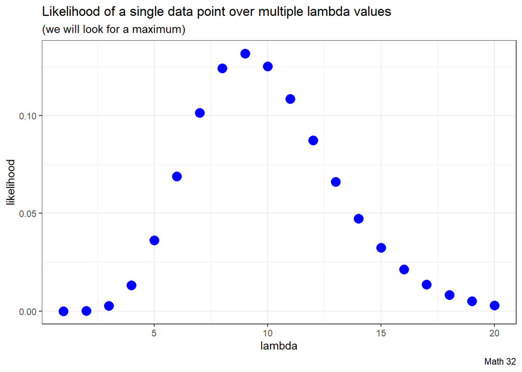

```r
# likelihood of a single data point, over a sequence of guesses for lambda
lambda_values <- seq(1, 20)
likelihood <- dpois(data_pois[1], lambda = lambda_values)

# arranged into a data frame
lh_single <- data.frame(lambda_values = lambda_values, likelihood = likelihood )

lh_single %>%
  ggplot(aes(x = lambda_values,y = likelihood))+
  geom_point(size = 4, color = "blue")+
  labs(title = "Likelihood of a single data point over multiple lambda values",
       subtitle = "(we will look for a maximum)",
       caption = "Math 32",
       x = "lambda",
       y = "likelihood") +
  theme_bw()
```

### Log-Likelihood

```r
# log-likelihood of a single data point, guessing lambda = 1
dpois(data_pois[1], lambda = 1, log = TRUE)
```

```
## [1] -13.80183
```

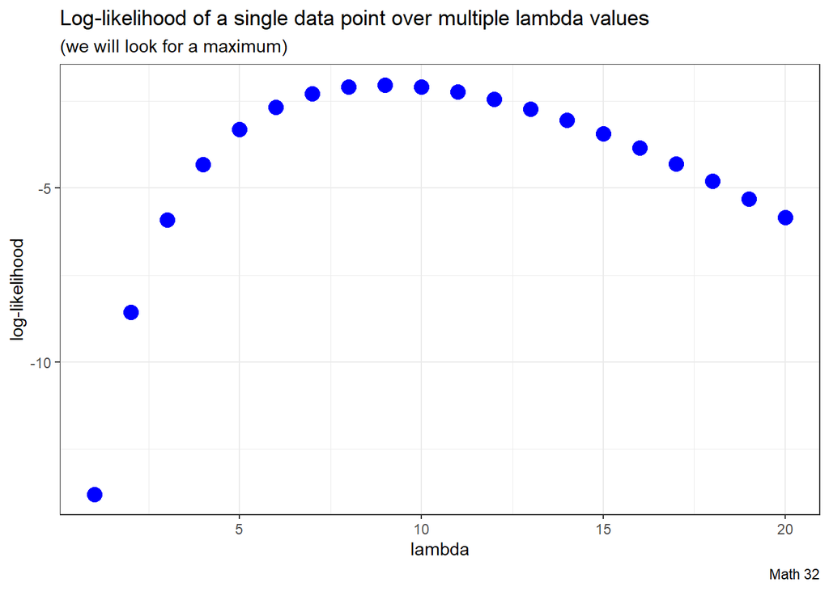

```r
# log-likelihood of a single data point, over a sequence of guesses for lambda
lambda_values <- seq(1, 20)
log_likelihood <- dpois(data_pois[1], lambda = lambda_values, log = TRUE)

# arranged into a data frame
lh_single <- data.frame(lambda_values = lambda_values, log_likelihood = log_likelihood)

lh_single %>%
  ggplot(aes(x = lambda_values,y = log_likelihood))+
  geom_point(size = 4, color = "blue")+
  labs(title = "Log-likelihood of a single data point over multiple lambda values",
       subtitle = "(we will look for a maximum)",
       caption = "Math 32",
       x = "lambda",
       y = "log-likelihood") +
  theme_bw()
```

### MLE over all values

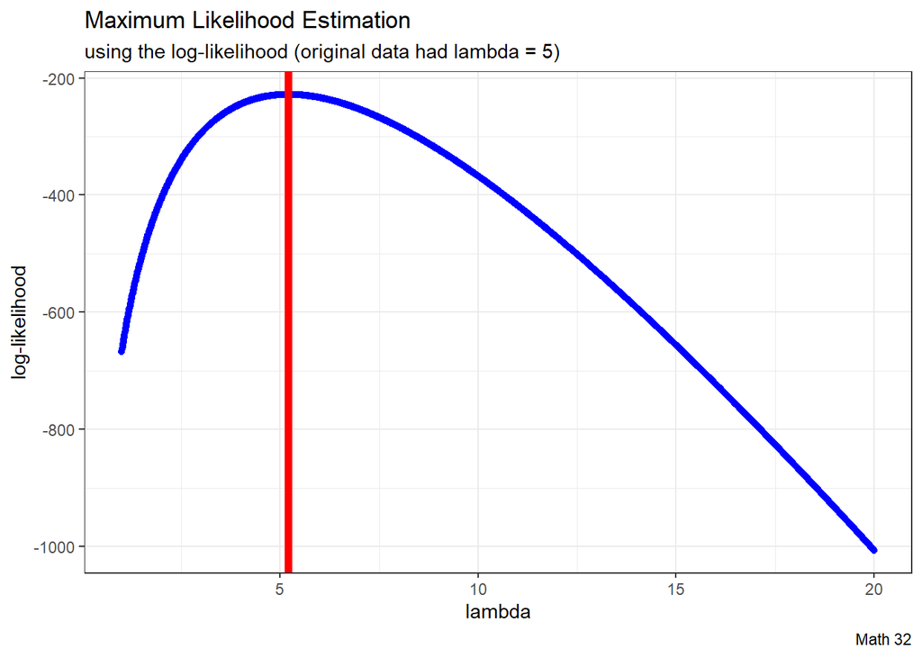

```r
LL_poisson <- function(lambda, y){
  # log-likelihood by summing
  LL <- sum(dpois(y, lambda, log=TRUE))
  return(LL)
}
lambda_values <- seq(1, 20, by = 0.01)

# compute log-likelihood for all data, for all lambda values
LL <- sapply(lambda_values, function(x){ LL_poisson(x, data_pois) })

# save the lambdas and log-likelihoods in a data frame
df <- data.frame(LL, lambda_values)

df %>%
  ggplot(aes(x = lambda_values,y = LL)) +
  geom_point(color = "blue") +
  geom_vline(xintercept = lambda_values[which.max(LL)], color = "red", size = 2) +
  labs(title = "Maximum Likelihood Estimation",
       subtitle = "using the log-likelihood (original data had lambda = 5)",
       caption = "Math 32",
       x = "lambda",
       y = "log-likelihood") +
  theme_bw()
```

```r
# the MLE value itself
lambda_values[which.max(LL)]
```

```
## [1] 5.21
```

# Exercises

## 1. MLE over an Uniform Distribution

Here we generate $n$ independent uniformly distributed random numbers ($x_1, x_2, \dots, x_n$) on an interval from $[0,a]$ where you specify the value of $a$.

```r
a <-32
N <- 100
data_unif <- runif(N, 0, a)
likelihood_unif <- function(a, data){
  temp <- dunif(data, 0, a)
  return(prod(temp, na.rm = TRUE))
}
```

### 1A

Describe the graph and calculations in your own words.

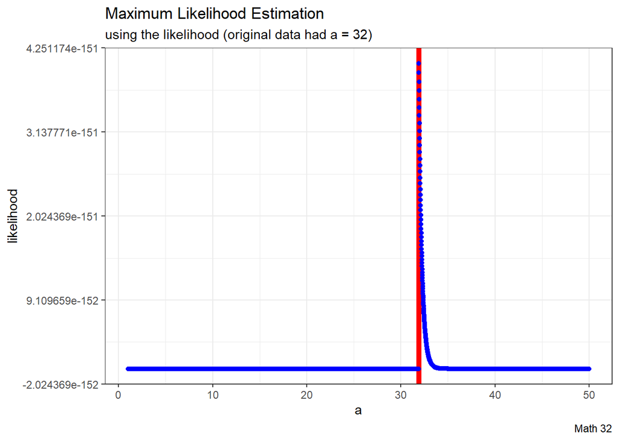

```r
# compute likelihood for all data, for many guesses at parameter a
a_values <- seq(1, 50, by = 0.01)
LH <- sapply(a_values, function(x){ likelihood_unif(x, data_unif) })
df <- data.frame(a_values, LH)

# graph the likelihood curve
df %>%
  ggplot(aes(x = a_values, y = LH)) +
  geom_vline(xintercept = a_values[which.max(LH)], color = "red", size = 2) +
  geom_point(color = "blue") +
  labs(title = "Maximum Likelihood Estimation",
       subtitle = "using the likelihood (original data had a = 32)",
       caption = "Math 32",
       x = "a",
       y = "likelihood") +
  theme_bw()
```

### 1B

Use a line of R code to empirically determine the maximum likelihood choice for $a$ from your likelihood.

```r
MLE = a_values[which.max(LH)]
```

## 2: MLE over an Exponential Distribution

The data file `obsExpData.csv` contains a data set of 1000 independent points sampled from an exponential distribution with unknown parameter $\lambda > 0$.

NOTE: If this next code block does not work for you, set `eval = FALSE` and re-run all of the `R` code blocks. However, you will need to be able to debug this error for next week’s homework (“put everything in your Math 32 folder”).

```r
data_obs <- read_csv("obsExpData.csv")
```

### 2A

Describe the following function

```r
LL_exp <- function(mu = 1, sample_data){
  lambda <- 1/mu
  n <- sum(!is.na(sample_data)) #sample size
  this_sum <- sum(sample_data, na.rm = TRUE)
  loglikelihood <- n*log(lambda) - this_sum * lambda
  loglikelihood #return
}
```

### 2B

Describe the graph and calculations in your own words.

For the calculations, mu_values is the parameter space. LL_values is the log-likelihoods for each parameter value of mu_values. LL_exp is the MLE over an exponential distribution. Then mu_values and log-likelihoods is saved in a data frame. For the graph, it shows how the log likelihood varies over different values of mu and the red vertical line shows the MLE of mu where the likelihood is highest.

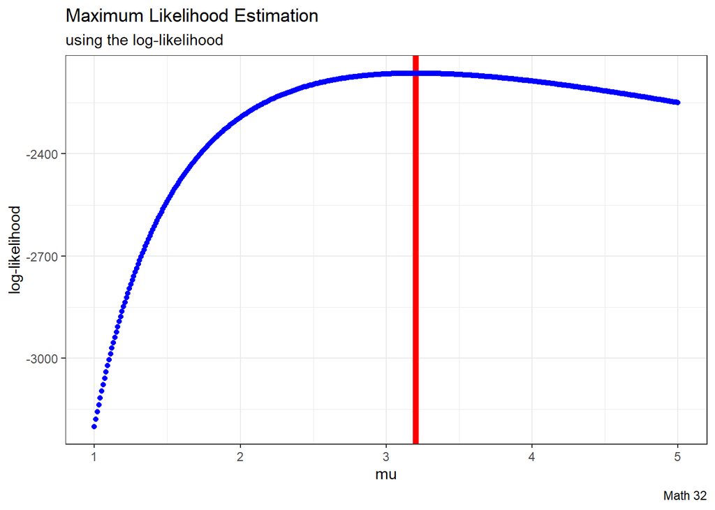

```r
# values to guess toward MLE
mu_values <- seq(1, 5, by = 0.01)

# compute log-likelihood for all data, for all lambda values
LL_values <- sapply(mu_values, function(x){ LL_exp(x, data_obs) })

# save the lambdas and log-likelihoods in a data frame
df <- data.frame(mu_values, LL_values)

df %>%
  ggplot(aes(x = mu_values, y = LL_values)) +
  geom_vline(xintercept = mu_values[which.max(LL_values)],
             color = "red", size = 2) +
  geom_point(color = "blue") +
  labs(title = "Maximum Likelihood Estimation",
       subtitle = "using the log-likelihood",
       caption = "Math 32",
       x = "mu",
       y = "log-likelihood") +
  theme_bw()
```

### 2C

Use a line of R code to empirically determine the maximum likelihood choice for $a$ from your likelihood.

```r
MLE = mu_values[which.max(LL_values)]
```

# Wrap-Up

## Reflection

Reflection: write at least two sentences below about this assignment.

I learned a lot from this assignment. As a CSE major, learning a new language was interesting.

## Submission

- Use the `Knit` button (at top of script editor) and `knit to HTML`
- upload today’s HTML back to our `CatCourses` page